## **Parma wallaby**

### Blamed on foxes

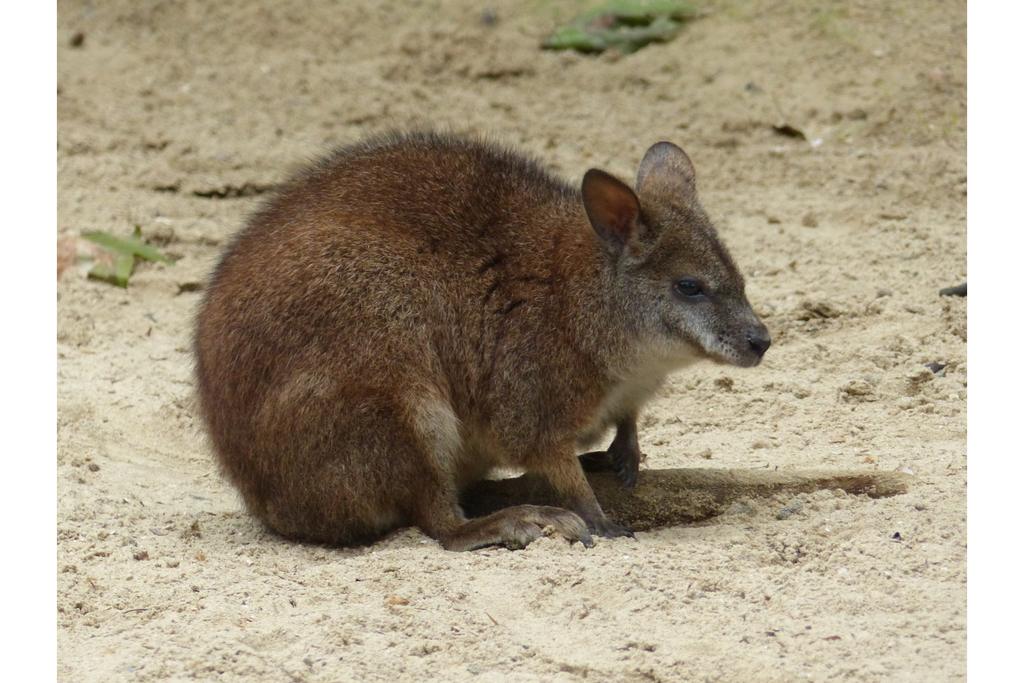

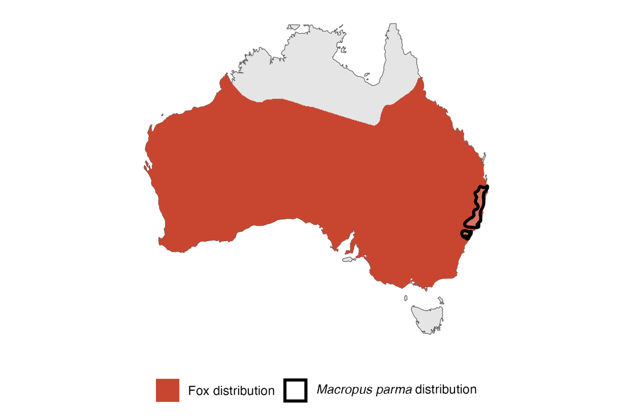

IUCN status: **Near Threatened**

EPBC Predator Threat Rating: **Not assessed**

IUCN claim: *“Forest fragmentation combined with predation from foxes appear to be the principal reasons for the decline of the species. Grazing and burning regimes that affect availability of shelter are a disadvantage to populations (Maxwell et al. 1996). Reintroductions of the species have been unsuccessful due to fox predation.”*

### Studies not in support

No studies

### Is the threat claim evidence-based?

No studies were found evidencing a negative association between foxes and parma wallaby populations. The fate of reintroduced animals is not a reliable proxy for the fate of populations.

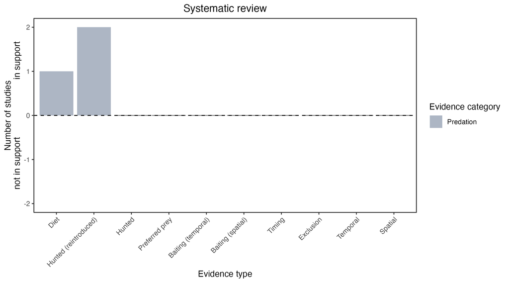

**Evidence linking *Macropus parma* to foxes.** Systematic review of evidence for an association between *Macropus parma* and foxes. Positive studies are in support of the hypothesis that *foxes* contribute to the decline of Macropus parma, negative studies are not in support. Predation studies include studies documenting hunting or scavenging; baiting studies are associations between poison baiting and threatened mammal abundance where information on predator abundance is not provided; population studies are associations between threatened mammal and predator abundance. Gold borders indicate studies that meet qualities of scientific rigour. See methods section in Wallach and Lundgren 2025 for details on evidence categories.

### References

Glen, A.S., Pennay, M., Dickman, C.R., Wintle, B.A. and Firestone, K.B., 2011. Diets of sympatric native and introduced carnivores in the Barrington Tops, eastern Australia. Austral Ecology, 36(3), pp.290-296.

IUCN Red List. https://www.iucnredlist.org/ Accessed June 2023

Short, J., Bradshaw, S.D., Giles, J., Prince, R.I.T. and Wilson, G.R., 1992. Reintroduction of macropods (Marsupialia: Macropodoidea) in Australia—a review. Biological Conservation, 62(3), pp.189-204.

Wallach A.D., Lundgren E.J. (2025) Review of evidence that foxes and cats cause extinctions of Australia’s endemic mammals. BioScience. DOI: 10.1093/biosci/biaf046